# Introduction to Computer Vision: Plant Seedlings Classification

## Problem Statement

### Context

In recent times, the field of agriculture has been in urgent need of modernizing, since the amount of manual work people need to put in to check if plants are growing correctly is still highly extensive. Despite several advances in agricultural technology, people working in the agricultural industry still need to have the ability to sort and recognize different plants and weeds, which takes a lot of time and effort in the long term. The potential is ripe for this trillion-dollar industry to be greatly impacted by technological innovations that cut down on the requirement for manual labor, and this is where Artificial Intelligence can actually benefit the workers in this field, as **the time and energy required to identify plant seedlings will be greatly shortened by the use of AI and Deep Learning.** The ability to do so far more efficiently and even more effectively than experienced manual labor, could lead to better crop yields, the freeing up of human inolvement for higher-order agricultural decision making, and in the long term will result in more sustainable environmental practices in agriculture as well.

### Objective

The aim of this project is to Build a Convolutional Neural Netowrk to classify plant seedlings into their respective categories.

### Data Dictionary

The Aarhus University Signal Processing group, in collaboration with the University of Southern Denmark, has recently released a dataset containing **images of unique plants belonging to 12 different species.**

- The dataset can be download from Olympus.
- The data file names are:
  - images.npy
  - Labels.csv
- Due to the large volume of data, the images were converted to the images.npy file and the labels are also put into Labels.csv, so that you can work on the data/project seamlessly without having to worry about the high data volume.
- The goal of the project is to create a classifier capable of determining a plant's species from an image.

**List of Species**

- Black-grass
- Charlock
- Cleavers
- Common Chickweed
- Common Wheat
- Fat Hen
- Loose Silky-bent
- Maize
- Scentless Mayweed
- Shepherds Purse
- Small-flowered Cranesbill
- Sugar beet

### **Note: Please use GPU runtime on Google Colab to execute the code faster.**

## Importing necessary libraries

```python
# Installing the libraries with the specified version.
# uncomment and run the following line if Google Colab is being used
# !pip install tensorflow==2.15.0 scikit-learn==1.2.2 seaborn==0.13.1 matplotlib==3.7.1 numpy==1.25.2 pandas==1.5.3 opencv-python==4.8.0.76 -q --user
```

```python
# Installing the libraries with the specified version.
# uncomment and run the following lines if Jupyter Notebook is being used
#!pip install tensorflow==2.13.0 scikit-learn==1.2.2 seaborn==0.11.1 matplotlib==3.3.4 numpy==1.24.3 pandas==1.5.2 opencv-python==4.8.0.76 -q --user
```

**Note**: *After running the above cell, kindly restart the notebook kernel and run all cells sequentially from the start again.*

```python
import os
import numpy as np                                                                               # Importing numpy for Matrix Operations
import pandas as pd                                                                              # Importing pandas to read CSV files
import matplotlib.pyplot as plt                                                                  # Importting matplotlib for Plotting and visualizing images
import math                                                                                      # Importing math module to perform mathematical operations
import cv2                                                                                       # Importing openCV for image processing
import seaborn as sns                                                                            # Importing seaborn to plot graphs


# Tensorflow modules
import tensorflow as tf
from tensorflow.keras.preprocessing.image import ImageDataGenerator                              # Importing the ImageDataGenerator for data augmentation
from tensorflow.keras.models import Sequential                                                   # Importing the sequential module to define a sequential model
from tensorflow.keras.layers import Dense,Dropout,Flatten,Conv2D,MaxPooling2D,BatchNormalization # Defining all the layers to build our CNN Model
from tensorflow.keras.optimizers import Adam,SGD                                                 # Importing the optimizers which can be used in our model
from sklearn import preprocessing                                                                # Importing the preprocessing module to preprocess the data
from sklearn.model_selection import train_test_split                                             # Importing train_test_split function to split the data into train and test
from sklearn.metrics import ConfusionMatrixDisplay                                               # Importing confusion_matrix to plot the confusion matrix
from tensorflow.keras.callbacks import EarlyStopping, ReduceLROnPlateau

# Display images using OpenCV
from google.colab.patches import cv2_imshow                                                      # Importing cv2_imshow from google.patches to display images

# Ignore warnings
import warnings
warnings.filterwarnings('ignore')
```

## Loading the dataset

```python
# Uncomment and run the below code if you are using google colab
from google.colab import drive
drive.mount('/content/drive')
```

```python
# Load the image file of the dataset
images = np.load('/content/drive/MyDrive/Colab Notebooks/images.npy')

# Load the labels file of the dataset
labels = pd.read_csv('/content/drive/MyDrive/Colab Notebooks/Labels.csv')
```

## Data Overview

### Understand the shape of the dataset

```python
print(images.shape)
print(labels.shape)
```

```
(4750, 128, 128, 3)
(4750, 1)
```

There are 4750 RGB images of shape 128 x 128 X 3, each image having 3 channels.

## Exploratory Data Analysis

- EDA is an important part of any project involving data.
- It is important to investigate and understand the data better before building a model with it.
- A few questions have been mentioned below which will help you understand the data better.
- A thorough analysis of the data, in addition to the questions mentioned below, should be done.
1. How are these different category plant images different from each other?
2. Is the dataset provided an imbalance? (Check with using bar plots)

```python
def plot_images(images,labels):
  num_classes=12                                                                  # Number of Classes
  categories=np.unique(labels)
  keys=dict(labels['Label'])                                                      # Obtaing the unique classes from y_train
  rows = 3                                                                        # Defining number of rows=3
  cols = 3                                                                        # Defining number of columns=3
  fig = plt.figure(figsize=(7, 5))                                               # Defining the figure size to 7x5
  for i in range(cols):
      for j in range(rows):
          random_index = np.random.randint(0, len(labels))                        # Generating random indices from the data and plotting the images
          ax = fig.add_subplot(rows, cols, i * rows + j + 1)                      # Adding subplots with 3 rows and 3 columns
          ax.imshow(images[random_index, :])                                      # Plotting the image
          ax.set_title(keys[random_index])
  plt.show()
```

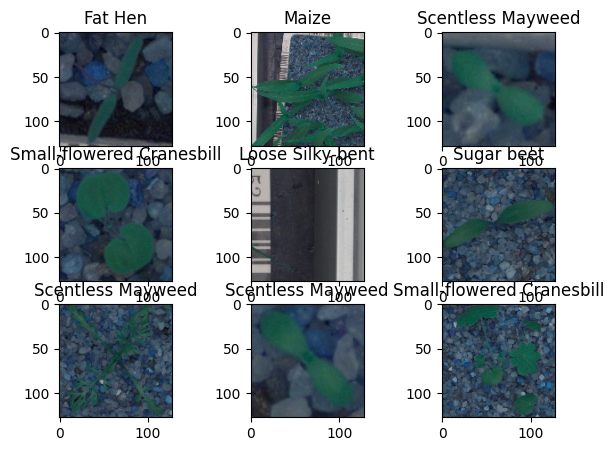

```python
plot_images(images,labels)
```

Checking for data imbalance

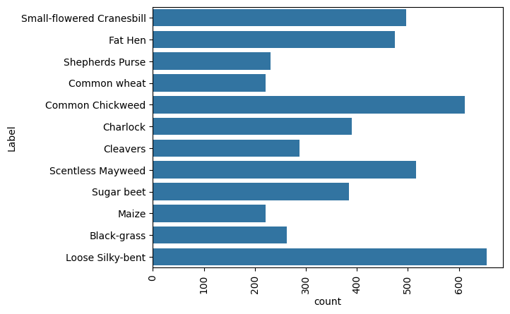

```python
 sns.countplot(labels['Label'])
 plt.xticks(rotation='vertical');
```

```python
# Get the count of each plant type
label_counts = labels['Label'].value_counts()

# Print the counts
print(label_counts)
```

```
Label
Loose Silky-bent             654
Common Chickweed             611
Scentless Mayweed            516
Small-flowered Cranesbill    496
Fat Hen                      475
Charlock                     390
Sugar beet                   385
Cleavers                     287
Black-grass                  263
Shepherds Purse              231
Common wheat                 221
Maize                        221
Name: count, dtype: int64
```

1. How are these different category plant images different from each other?

The dataset contains 12 different categories. Common wheat and Maize are the classes with least number of images. Loose silky bent and common chickweed are classes with most number of images

The images have distinct characteristics which can help the CNN identify them. However, certain images are blurry or dark, which will be difficult to analyze for the CNN. Data Augmentation could help overcome this issue.

2. Is the dataset provided an imbalance? (Check with using bar plots)

As we can see from the above plot, the dataset is quite imbalanced. This imbalance can affect the model's performance, as the model might become biased due to the more prevelant classes.

## Data Pre-Processing

### Convert the BGR images to RGB images.

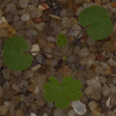

```python
cv2_imshow(images[1])
```

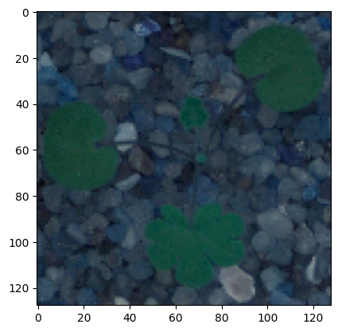

```python
plt.imshow(images[1])
```

We can observe that the images plotted with openCV are brighter and sharper when compared to the images plotted with matplotlib.

The reason for this difference in image display is openCV reading images in BGR format while matplotlib reading images in RGB format

Now we will convert these BGR images to RGB images so we could interpret them easily.

```python
# Converting the images from BGR to RGB using cvtColor function of OpenCV
for i in range(len(images)):
  images[i] = cv2.cvtColor(images[i], cv2.COLOR_BGR2RGB)
```

### Resize the images

As the size of the images is large, it may be computationally expensive to train on these larger images; therefore, it is preferable to reduce the image size from 128 to 64.

```python
images_decreased=[]
height = 64
width = 64
dimensions = (width, height)
for i in range(len(images)):
  images_decreased.append( cv2.resize(images[i], dimensions, interpolation=cv2.INTER_LINEAR))
```

Compare original image and resized image

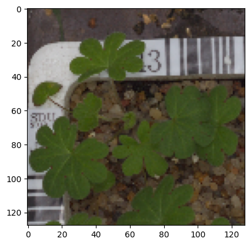

```python
plt.imshow(images[3])
```

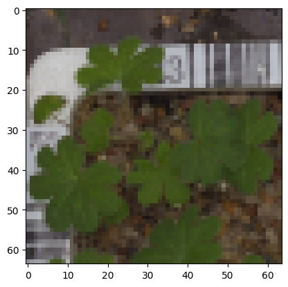

```python
plt.imshow(images_decreased[3])
```

### Data Preparation for Modeling

- Before you proceed to build a model, you need to split the data into train, test, and validation to be able to evaluate the model that you build on the train data
- You'll have to encode categorical features and scale the pixel values.
- You will build a model using the train data and then check its performance

**Split the dataset**

As we have less images in our dataset, we will only use 10% of our data for testing, 10% of our data for validation and 80% of our data for training.

We are using the train_test_split() function from scikit-learn. Here, we split the dataset into three parts, train,test and validation.

```python
X_train, X_test, y_train, y_test = train_test_split(np.array(images_decreased),labels , test_size=0.2, random_state=42,stratify=labels)

X_test, X_val, y_test, y_val = train_test_split(X_test,y_test , test_size=0.5, random_state=42,stratify=y_test)

print(X_train.shape,y_train.shape)
print(X_val.shape,y_val.shape)
print(X_test.shape,y_test.shape)
```

```
(3800, 64, 64, 3) (3800, 1)
(475, 64, 64, 3) (475, 1)
(475, 64, 64, 3) (475, 1)
```

### Encode the target labels

```python
# Convert labels from names to one hot vectors.
# We have already used encoding methods like onehotencoder and labelencoder earlier so now we will be using a new encoding method called labelBinarizer.
# Labelbinarizer works similar to onehotencoder

from sklearn.preprocessing import LabelBinarizer
enc = LabelBinarizer()
y_train_encoded = enc.fit_transform(y_train)
y_val_encoded=enc.transform(y_val)
y_test_encoded=enc.transform(y_test)
```

### Data Normalization

Since the image pixel values range from 0-255, our method of normalization here will be scaling.

We shall divide all the pixel values by 255 to standardize the images to have values between 0-1.

```python
# Normalizing the image pixels
X_train_normalized = X_train.astype('float32')/255.0
X_val_normalized = X_val.astype('float32')/255.0
X_test_normalized = X_test.astype('float32')/255.0
```

## Model Building

Model 1 : Basic Convolution Neural Network trained from the original dataset

Model 1 will be a CNN model created sequentially, with convolution layers, Pooling layers and fully connected layers

Before building the model, we need to clear the previous model's history from the session.

Also, let's set the seed for random number generators in Numpy, the Random library in Python, and in TensorFlow to be able to reproduce the same results every time we run the code.

```python
# Clearing backend
from tensorflow.keras import backend
backend.clear_session()

# Fixing the seed for random number generators
import random
np.random.seed(42)
random.seed(42)
tf.random.set_seed(42)
```

```python
# Intializing a sequential model
model1 = Sequential()

# Adding first conv layer with 32 filters and kernel size 3x3 , padding 'same'
model1.add(Conv2D(32, (3, 3), activation='relu', padding="same", input_shape=(64, 64, 3)))
model1.add(MaxPooling2D((2, 2), padding = 'same'))

# Adding second conv layer with 64 filters and kernel size 3x3 , padding 'same'
model1.add(Conv2D(64, (3, 3), activation='relu', padding="same"))
model1.add(MaxPooling2D((2, 2), padding = 'same'))
model1.add(BatchNormalization())

# Adding third conv layer with 128 filters and kernel size 3x3 , padding 'same'
model1.add(Conv2D(128, (3, 3), activation='relu', padding="same"))
model1.add(MaxPooling2D((2, 2), padding = 'same'))

# Adding fourth conv layer with 256 filters and kernel size 3x3 , padding 'same'
model1.add(Conv2D(256, (3, 3), activation='relu', padding="same"))
model1.add(MaxPooling2D((2, 2), padding = 'same'))
model1.add(Dropout(0.3))

# flattening the output of the conv layer after max pooling to make it ready for creating dense connections
model1.add(Flatten())

# Adding a fully connected dense layer with 100 neurons
model1.add(Dense(16, activation='relu'))
model1.add(Dropout(0.3))

# Adding the output layer with 10 neurons and activation functions as softmax since this is a multi-class classification problem
model1.add(Dense(12, activation='softmax'))

# Using Adam Optimizer
opt=Adam()

# Compile model
model1.compile(optimizer=opt, loss='categorical_crossentropy', metrics=['accuracy'])

# Generating the summary of the model
model1.summary()
```

```
Model: "sequential"
```

```
┏━━━━━━━━━━━━━━━━━━━━━━━━━━━━━━━━━━━━━━┳━━━━━━━━━━━━━━━━━━━━━━━━━━━━━┳━━━━━━━━━━━━━━━━━┓
┃ Layer (type)                         ┃ Output Shape                ┃         Param # ┃
┡━━━━━━━━━━━━━━━━━━━━━━━━━━━━━━━━━━━━━━╇━━━━━━━━━━━━━━━━━━━━━━━━━━━━━╇━━━━━━━━━━━━━━━━━┩
│ conv2d (Conv2D)                      │ (None, 64, 64, 32)          │             896 │
├──────────────────────────────────────┼─────────────────────────────┼─────────────────┤
│ max_pooling2d (MaxPooling2D)         │ (None, 32, 32, 32)          │               0 │
├──────────────────────────────────────┼─────────────────────────────┼─────────────────┤
│ conv2d_1 (Conv2D)                    │ (None, 32, 32, 64)          │          18,496 │
├──────────────────────────────────────┼─────────────────────────────┼─────────────────┤
│ max_pooling2d_1 (MaxPooling2D)       │ (None, 16, 16, 64)          │               0 │
├──────────────────────────────────────┼─────────────────────────────┼─────────────────┤
│ batch_normalization                  │ (None, 16, 16, 64)          │             256 │
│ (BatchNormalization)                 │                             │                 │
├──────────────────────────────────────┼─────────────────────────────┼─────────────────┤
│ conv2d_2 (Conv2D)                    │ (None, 16, 16, 128)         │          73,856 │
├──────────────────────────────────────┼─────────────────────────────┼─────────────────┤
│ max_pooling2d_2 (MaxPooling2D)       │ (None, 8, 8, 128)           │               0 │
├──────────────────────────────────────┼─────────────────────────────┼─────────────────┤
│ conv2d_3 (Conv2D)                    │ (None, 8, 8, 256)           │         295,168 │
├──────────────────────────────────────┼─────────────────────────────┼─────────────────┤
│ max_pooling2d_3 (MaxPooling2D)       │ (None, 4, 4, 256)           │               0 │
├──────────────────────────────────────┼─────────────────────────────┼─────────────────┤
│ dropout (Dropout)                    │ (None, 4, 4, 256)           │               0 │
├──────────────────────────────────────┼─────────────────────────────┼─────────────────┤
│ flatten (Flatten)                    │ (None, 4096)                │               0 │
├──────────────────────────────────────┼─────────────────────────────┼─────────────────┤
│ dense (Dense)                        │ (None, 16)                  │          65,552 │
├──────────────────────────────────────┼─────────────────────────────┼─────────────────┤
│ dropout_1 (Dropout)                  │ (None, 16)                  │               0 │
├──────────────────────────────────────┼─────────────────────────────┼─────────────────┤
│ dense_1 (Dense)                      │ (None, 12)                  │             204 │
└──────────────────────────────────────┴─────────────────────────────┴─────────────────┘
```

```
 Total params: 454,428 (1.73 MB)
```

```
 Trainable params: 454,300 (1.73 MB)
```

```
 Non-trainable params: 128 (512.00 B)
```

```python
# Fitting the model on training data
history_1 = model1.fit(
            X_train_normalized, y_train_encoded,
            epochs=50,
            validation_data=(X_val_normalized,y_val_encoded),
            batch_size=32,
            verbose=1,
            #callbacks=callbacks
)
```

```
119/119 ━━━━━━━━━━━━━━━━━━━━ 10s 43ms/step - accuracy: 0.1414 - loss: 2.4444 - val_accuracy: 0.1895 - val_loss: 2.4536
119/119 ━━━━━━━━━━━━━━━━━━━━ 4s 8ms/step - accuracy: 0.2351 - loss: 2.2420 - val_accuracy: 0.3032 - val_loss: 2.3990
119/119 ━━━━━━━━━━━━━━━━━━━━ 1s 7ms/step - accuracy: 0.2796 - loss: 2.1313 - val_accuracy: 0.3074 - val_loss: 2.3172
119/119 ━━━━━━━━━━━━━━━━━━━━ 1s 7ms/step - accuracy: 0.2803 - loss: 2.0657 - val_accuracy: 0.3684 - val_loss: 2.1164
119/119 ━━━━━━━━━━━━━━━━━━━━ 1s 7ms/step - accuracy: 0.2817 - loss: 2.0302 - val_accuracy: 0.3895 - val_loss: 1.9286
119/119 ━━━━━━━━━━━━━━━━━━━━ 1s 9ms/step - accuracy: 0.2932 - loss: 1.9759 - val_accuracy: 0.3747 - val_loss: 1.9036
119/119 ━━━━━━━━━━━━━━━━━━━━ 1s 9ms/step - accuracy: 0.2937 - loss: 1.9653 - val_accuracy: 0.3979 - val_loss: 1.7298
119/119 ━━━━━━━━━━━━━━━━━━━━ 1s 7ms/step - accuracy: 0.3033 - loss: 1.9310 - val_accuracy: 0.3937 - val_loss: 1.7273
119/119 ━━━━━━━━━━━━━━━━━━━━ 1s 7ms/step - accuracy: 0.3294 - loss: 1.8610 - val_accuracy: 0.4421 - val_loss: 1.6883
119/119 ━━━━━━━━━━━━━━━━━━━━ 1s 7ms/step - accuracy: 0.3665 - loss: 1.7794 - val_accuracy: 0.4779 - val_loss: 1.5290
119/119 ━━━━━━━━━━━━━━━━━━━━ 1s 7ms/step - accuracy: 0.4229 - loss: 1.5789 - val_accuracy: 0.5116 - val_loss: 1.4582
119/119 ━━━━━━━━━━━━━━━━━━━━ 1s 8ms/step - accuracy: 0.4359 - loss: 1.5266 - val_accuracy: 0.5768 - val_loss: 1.2393
119/119 ━━━━━━━━━━━━━━━━━━━━ 1s 8ms/step - accuracy: 0.4579 - loss: 1.4659 - val_accuracy: 0.5137 - val_loss: 1.4859
119/119 ━━━━━━━━━━━━━━━━━━━━ 1s 8ms/step - accuracy: 0.4614 - loss: 1.3984 - val_accuracy: 0.5684 - val_loss: 1.2010
119/119 ━━━━━━━━━━━━━━━━━━━━ 1s 7ms/step - accuracy: 0.4961 - loss: 1.3285 - val_accuracy: 0.6021 - val_loss: 1.1724
119/119 ━━━━━━━━━━━━━━━━━━━━ 1s 8ms/step - accuracy: 0.5143 - loss: 1.2826 - val_accuracy: 0.5663 - val_loss: 1.2837
119/119 ━━━━━━━━━━━━━━━━━━━━ 1s 9ms/step - accuracy: 0.5222 - loss: 1.2706 - val_accuracy: 0.6232 - val_loss: 1.1336
119/119 ━━━━━━━━━━━━━━━━━━━━ 1s 9ms/step - accuracy: 0.5429 - loss: 1.2107 - val_accuracy: 0.6526 - val_loss: 1.0206
119/119 ━━━━━━━━━━━━━━━━━━━━ 1s 8ms/step - accuracy: 0.5298 - loss: 1.2179 - val_accuracy: 0.6674 - val_loss: 1.0332
119/119 ━━━━━━━━━━━━━━━━━━━━ 1s 8ms/step - accuracy: 0.5415 - loss: 1.2084 - val_accuracy: 0.6737 - val_loss: 1.0747
119/119 ━━━━━━━━━━━━━━━━━━━━ 1s 7ms/step - accuracy: 0.5747 - loss: 1.1299 - val_accuracy: 0.7032 - val_loss: 0.9854
119/119 ━━━━━━━━━━━━━━━━━━━━ 1s 7ms/step - accuracy: 0.5660 - loss: 1.1545 - val_accuracy: 0.7158 - val_loss: 0.9243
119/119 ━━━━━━━━━━━━━━━━━━━━ 1s 7ms/step - accuracy: 0.5725 - loss: 1.1010 - val_accuracy: 0.6884 - val_loss: 0.9489
119/119 ━━━━━━━━━━━━━━━━━━━━ 1s 7ms/step - accuracy: 0.6005 - loss: 1.0688 - val_accuracy: 0.7179 - val_loss: 1.0075
119/119 ━━━━━━━━━━━━━━━━━━━━ 1s 7ms/step - accuracy: 0.6207 - loss: 1.0164 - val_accuracy: 0.6653 - val_loss: 1.1568
119/119 ━━━━━━━━━━━━━━━━━━━━ 1s 7ms/step - accuracy: 0.6281 - loss: 0.9809 - val_accuracy: 0.7326 - val_loss: 0.9260
119/119 ━━━━━━━━━━━━━━━━━━━━ 1s 7ms/step - accuracy: 0.6359 - loss: 0.9441 - val_accuracy: 0.7537 - val_loss: 0.8692
119/119 ━━━━━━━━━━━━━━━━━━━━ 1s 8ms/step - accuracy: 0.6552 - loss: 0.9159 - val_accuracy: 0.6674 - val_loss: 1.1936
119/119 ━━━━━━━━━━━━━━━━━━━━ 1s 9ms/step - accuracy: 0.6431 - loss: 0.9368 - val_accuracy: 0.5642 - val_loss: 1.4062
119/119 ━━━━━━━━━━━━━━━━━━━━ 1s 9ms/step - accuracy: 0.6543 - loss: 0.8952 - val_accuracy: 0.7411 - val_loss: 0.8664
119/119 ━━━━━━━━━━━━━━━━━━━━ 1s 7ms/step - accuracy: 0.6728 - loss: 0.8521 - val_accuracy: 0.4042 - val_loss: 1.8535
119/119 ━━━━━━━━━━━━━━━━━━━━ 1s 7ms/step - accuracy: 0.6605 - loss: 0.8703 - val_accuracy: 0.6505 - val_loss: 1.1558
119/119 ━━━━━━━━━━━━━━━━━━━━ 1s 7ms/step - accuracy: 0.6869 - loss: 0.8284 - val_accuracy: 0.7642 - val_loss: 0.8893
119/119 ━━━━━━━━━━━━━━━━━━━━ 1s 7ms/step - accuracy: 0.6925 - loss: 0.7751 - val_accuracy: 0.7263 - val_loss: 0.9881
119/119 ━━━━━━━━━━━━━━━━━━━━ 1s 7ms/step - accuracy: 0.6642 - loss: 0.8313 - val_accuracy: 0.6989 - val_loss: 1.0442
119/119 ━━━━━━━━━━━━━━━━━━━━ 1s 7ms/step - accuracy: 0.7124 - loss: 0.7381 - val_accuracy: 0.7432 - val_loss: 0.8421
119/119 ━━━━━━━━━━━━━━━━━━━━ 1s 7ms/step - accuracy: 0.6900 - loss: 0.7734 - val_accuracy: 0.6947 - val_loss: 1.1386
119/119 ━━━━━━━━━━━━━━━━━━━━ 1s 7ms/step - accuracy: 0.6939 - loss: 0.7491 - val_accuracy: 0.6737 - val_loss: 1.1715
119/119 ━━━━━━━━━━━━━━━━━━━━ 1s 7ms/step - accuracy: 0.7030 - loss: 0.7213 - val_accuracy: 0.7853 - val_loss: 0.8201
119/119 ━━━━━━━━━━━━━━━━━━━━ 1s 9ms/step - accuracy: 0.6977 - loss: 0.7338 - val_accuracy: 0.6589 - val_loss: 1.3760
119/119 ━━━━━━━━━━━━━━━━━━━━ 1s 9ms/step - accuracy: 0.6887 - loss: 0.7639 - val_accuracy: 0.7747 - val_loss: 0.9243
119/119 ━━━━━━━━━━━━━━━━━━━━ 1s 9ms/step - accuracy: 0.6989 - loss: 0.7158 - val_accuracy: 0.7579 - val_loss: 0.9842
119/119 ━━━━━━━━━━━━━━━━━━━━ 1s 7ms/step - accuracy: 0.7300 - loss: 0.6573 - val_accuracy: 0.7600 - val_loss: 0.9789
119/119 ━━━━━━━━━━━━━━━━━━━━ 1s 7ms/step - accuracy: 0.7229 - loss: 0.6866 - val_accuracy: 0.7705 - val_loss: 0.8910
119/119 ━━━━━━━━━━━━━━━━━━━━ 1s 7ms/step - accuracy: 0.7245 - loss: 0.6400 - val_accuracy: 0.7579 - val_loss: 1.0443
119/119 ━━━━━━━━━━━━━━━━━━━━ 1s 7ms/step - accuracy: 0.7151 - loss: 0.7036 - val_accuracy: 0.7516 - val_loss: 0.9478
119/119 ━━━━━━━━━━━━━━━━━━━━ 1s 7ms/step - accuracy: 0.7242 - loss: 0.6668 - val_accuracy: 0.7705 - val_loss: 0.9636
119/119 ━━━━━━━━━━━━━━━━━━━━ 1s 7ms/step - accuracy: 0.7134 - loss: 0.6938 - val_accuracy: 0.7600 - val_loss: 1.0250
119/119 ━━━━━━━━━━━━━━━━━━━━ 1s 7ms/step - accuracy: 0.7227 - loss: 0.6510 - val_accuracy: 0.7263 - val_loss: 1.0328
119/119 ━━━━━━━━━━━━━━━━━━━━ 1s 7ms/step - accuracy: 0.7232 - loss: 0.6745 - val_accuracy: 0.7811 - val_loss: 0.7530
```

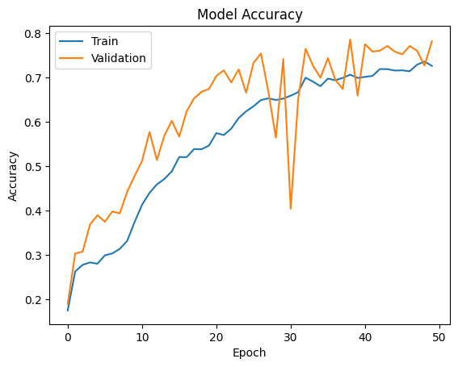

```python
# Model Evaluation
plt.plot(history_1.history['accuracy'])
plt.plot(history_1.history['val_accuracy'])
plt.title('Model Accuracy')
plt.ylabel('Accuracy')
plt.xlabel('Epoch')
plt.legend(['Train', 'Validation'], loc='upper left')
plt.show()
```

Observations:

We can see from the above plot that the training and validationaccuracy of the model are ok.

The model does not seem to overfit on the data. However, the graph is noisy

```python
# Evaluate model on test data
accuracy = model1.evaluate(X_test_normalized, y_test_encoded, verbose=2)
```

```
15/15 - 0s - 6ms/step - accuracy: 0.7600 - loss: 0.8729
```

```python
# Generate predictions on test data
# Here we would get the output as probablities for each category
y_pred=model1.predict(X_test_normalized)
```

```
15/15 ━━━━━━━━━━━━━━━━━━━━ 1s 26ms/step
```

```
<sklearn.metrics._plot.confusion_matrix.ConfusionMatrixDisplay at 0x7c772543a350>
```

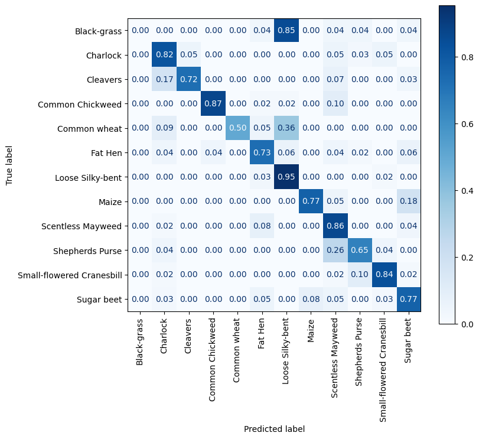

```python
# Obtaining the categorical values from y_test_encoded and y_pred
y_pred_arg=np.argmax(y_pred,axis=1)
y_test_arg=np.argmax(y_test_encoded,axis=1) # argmax() function to obtain the maximum value over each category and obtain their respective classes

# Plotting the Confusion Matrix using confusion matrix() function which is also predefined tensorflow module
confusion_matrix = tf.math.confusion_matrix(y_test_arg,y_pred_arg)
f, ax = plt.subplots(figsize=(8, 7))
ConfusionMatrixDisplay.from_predictions(
    y_test_arg, y_pred_arg,
    display_labels=enc.classes_,
    cmap='Blues',
    ax=ax,
    normalize='true',
    xticks_rotation='vertical',
    values_format='.2f'
)
```

Observations

We observe that some of the classes are not predicted correctly. Class 6 is very well classified with the highest % of accurate predictions

We can also observe that classes 0,4 are mostly misclassified.

Class0 is always misclassified

## Model Performance Improvement

**Reducing the Learning Rate:**

**Hint**: Use **ReduceLRonPlateau()** function that will be used to decrease the learning rate by some factor, if the loss is not decreasing for some time. This may start decreasing the loss at a smaller learning rate. There is a possibility that the loss may still not decrease. This may lead to executing the learning rate reduction again in an attempt to achieve a lower loss.

Model 2: Basic Convolution Neural Network trained from the original dataset with Early stopping and **ReduceLRonPlateau**

Model 2 will be a CNN model created sequentially, with convolution layers, Pooling layers and fully connected layers with callbacks implemented

Before building the model, we need to clear the previous model's history from the session.

Also, let's set the seed for random number generators in Numpy, the Random library in Python, and in TensorFlow to be able to reproduce the same results every time we run the code.

```python
# Clearing backend
from tensorflow.keras import backend
backend.clear_session()

# Fixing the seed for random number generators
import random
np.random.seed(42)
random.seed(42)
tf.random.set_seed(42)
```

```python
# Intializing a sequential model
model2 = Sequential()

# Adding first conv layer with 32 filters and kernel size 3x3 , padding 'same'
model2.add(Conv2D(32, (3, 3), activation='relu', padding="same", input_shape=(64, 64, 3)))
model2.add(MaxPooling2D((2, 2), padding = 'same'))

# Adding second conv layer with 64 filters and kernel size 3x3 , padding 'same'
model2.add(Conv2D(64, (3, 3), activation='relu', padding="same"))
model2.add(MaxPooling2D((2, 2), padding = 'same'))
model2.add(BatchNormalization())

# Adding third conv layer with 128 filters and kernel size 3x3 , padding 'same'
model2.add(Conv2D(128, (3, 3), activation='relu', padding="same"))
model2.add(MaxPooling2D((2, 2), padding = 'same'))

# Adding fourth conv layer with 256 filters and kernel size 3x3 , padding 'same'
model2.add(Conv2D(256, (3, 3), activation='relu', padding="same"))
model2.add(MaxPooling2D((2, 2), padding = 'same'))
model2.add(Dropout(0.3))

# flattening the output of the conv layer after max pooling to make it ready for creating dense connections
model2.add(Flatten())

# Adding a fully connected dense layer with 100 neurons
model2.add(Dense(16, activation='relu'))
model2.add(Dropout(0.3))

# Adding the output layer with 10 neurons and activation functions as softmax since this is a multi-class classification problem
model2.add(Dense(12, activation='softmax'))

# Using Adam Optimizer
opt=Adam()

# Compile model
model2.compile(optimizer=opt, loss='categorical_crossentropy', metrics=['accuracy'])

# Generating the summary of the model
model2.summary()
```

```
Model: "sequential"
```

```
┏━━━━━━━━━━━━━━━━━━━━━━━━━━━━━━━━━━━━━━┳━━━━━━━━━━━━━━━━━━━━━━━━━━━━━┳━━━━━━━━━━━━━━━━━┓
┃ Layer (type)                         ┃ Output Shape                ┃         Param # ┃
┡━━━━━━━━━━━━━━━━━━━━━━━━━━━━━━━━━━━━━━╇━━━━━━━━━━━━━━━━━━━━━━━━━━━━━╇━━━━━━━━━━━━━━━━━┩
│ conv2d (Conv2D)                      │ (None, 64, 64, 32)          │             896 │
├──────────────────────────────────────┼─────────────────────────────┼─────────────────┤
│ max_pooling2d (MaxPooling2D)         │ (None, 32, 32, 32)          │               0 │
├──────────────────────────────────────┼─────────────────────────────┼─────────────────┤
│ conv2d_1 (Conv2D)                    │ (None, 32, 32, 64)          │          18,496 │
├──────────────────────────────────────┼─────────────────────────────┼─────────────────┤
│ max_pooling2d_1 (MaxPooling2D)       │ (None, 16, 16, 64)          │               0 │
├──────────────────────────────────────┼─────────────────────────────┼─────────────────┤
│ batch_normalization                  │ (None, 16, 16, 64)          │             256 │
│ (BatchNormalization)                 │                             │                 │
├──────────────────────────────────────┼─────────────────────────────┼─────────────────┤
│ conv2d_2 (Conv2D)                    │ (None, 16, 16, 128)         │          73,856 │
├──────────────────────────────────────┼─────────────────────────────┼─────────────────┤
│ max_pooling2d_2 (MaxPooling2D)       │ (None, 8, 8, 128)           │               0 │
├──────────────────────────────────────┼─────────────────────────────┼─────────────────┤
│ conv2d_3 (Conv2D)                    │ (None, 8, 8, 256)           │         295,168 │
├──────────────────────────────────────┼─────────────────────────────┼─────────────────┤
│ max_pooling2d_3 (MaxPooling2D)       │ (None, 4, 4, 256)           │               0 │
├──────────────────────────────────────┼─────────────────────────────┼─────────────────┤
│ dropout (Dropout)                    │ (None, 4, 4, 256)           │               0 │
├──────────────────────────────────────┼─────────────────────────────┼─────────────────┤
│ flatten (Flatten)                    │ (None, 4096)                │               0 │
├──────────────────────────────────────┼─────────────────────────────┼─────────────────┤
│ dense (Dense)                        │ (None, 16)                  │          65,552 │
├──────────────────────────────────────┼─────────────────────────────┼─────────────────┤
│ dropout_1 (Dropout)                  │ (None, 16)                  │               0 │
├──────────────────────────────────────┼─────────────────────────────┼─────────────────┤
│ dense_1 (Dense)                      │ (None, 12)                  │             204 │
└──────────────────────────────────────┴─────────────────────────────┴─────────────────┘
```

```
 Total params: 454,428 (1.73 MB)
```

```
 Trainable params: 454,300 (1.73 MB)
```

```
 Non-trainable params: 128 (512.00 B)
```

```python
es_cb = EarlyStopping(
    monitor='val_accuracy',
    patience=10,
    verbose=1,
    restore_best_weights=True,
    # start_from_epoch=10
)

rlrop_cb = ReduceLROnPlateau(
    monitor='val_accuracy',
    patience=7,
    verbose=1
)

callbacks = [es_cb, rlrop_cb]
```

```python
# Fitting the model on training data
history_2 = model2.fit(
            X_train_normalized, y_train_encoded,
            epochs=100,
            validation_data=(X_val_normalized,y_val_encoded),
            batch_size=32,
            verbose=1,
            callbacks=callbacks
)
```

```
119/119 ━━━━━━━━━━━━━━━━━━━━ 10s 47ms/step - accuracy: 0.1425 - loss: 2.4450 - val_accuracy: 0.2274 - val_loss: 2.4479 - learning_rate: 0.0010
119/119 ━━━━━━━━━━━━━━━━━━━━ 1s 9ms/step - accuracy: 0.2186 - loss: 2.2166 - val_accuracy: 0.2379 - val_loss: 2.4097 - learning_rate: 0.0010
119/119 ━━━━━━━━━━━━━━━━━━━━ 1s 8ms/step - accuracy: 0.3012 - loss: 2.0516 - val_accuracy: 0.3200 - val_loss: 2.2332 - learning_rate: 0.0010
119/119 ━━━━━━━━━━━━━━━━━━━━ 1s 7ms/step - accuracy: 0.2875 - loss: 1.9978 - val_accuracy: 0.3516 - val_loss: 2.0569 - learning_rate: 0.0010
119/119 ━━━━━━━━━━━━━━━━━━━━ 1s 7ms/step - accuracy: 0.2963 - loss: 1.9511 - val_accuracy: 0.2947 - val_loss: 1.9771 - learning_rate: 0.0010
119/119 ━━━━━━━━━━━━━━━━━━━━ 1s 7ms/step - accuracy: 0.3086 - loss: 1.9118 - val_accuracy: 0.4000 - val_loss: 1.8093 - learning_rate: 0.0010
119/119 ━━━━━━━━━━━━━━━━━━━━ 1s 8ms/step - accuracy: 0.3182 - loss: 1.8610 - val_accuracy: 0.4316 - val_loss: 1.6953 - learning_rate: 0.0010
119/119 ━━━━━━━━━━━━━━━━━━━━ 1s 7ms/step - accuracy: 0.3430 - loss: 1.8278 - val_accuracy: 0.3937 - val_loss: 1.7111 - learning_rate: 0.0010
119/119 ━━━━━━━━━━━━━━━━━━━━ 1s 9ms/step - accuracy: 0.3586 - loss: 1.7594 - val_accuracy: 0.4232 - val_loss: 1.6672 - learning_rate: 0.0010
119/119 ━━━━━━━━━━━━━━━━━━━━ 1s 9ms/step - accuracy: 0.3701 - loss: 1.7373 - val_accuracy: 0.4442 - val_loss: 1.5808 - learning_rate: 0.0010
119/119 ━━━━━━━━━━━━━━━━━━━━ 1s 9ms/step - accuracy: 0.3870 - loss: 1.7220 - val_accuracy: 0.4400 - val_loss: 1.5683 - learning_rate: 0.0010
119/119 ━━━━━━━━━━━━━━━━━━━━ 1s 7ms/step - accuracy: 0.3800 - loss: 1.7259 - val_accuracy: 0.4126 - val_loss: 1.6763 - learning_rate: 0.0010
119/119 ━━━━━━━━━━━━━━━━━━━━ 1s 8ms/step - accuracy: 0.3959 - loss: 1.6607 - val_accuracy: 0.4400 - val_loss: 1.6146 - learning_rate: 0.0010
119/119 ━━━━━━━━━━━━━━━━━━━━ 1s 7ms/step - accuracy: 0.4006 - loss: 1.6530 - val_accuracy: 0.4716 - val_loss: 1.5544 - learning_rate: 0.0010
119/119 ━━━━━━━━━━━━━━━━━━━━ 1s 8ms/step - accuracy: 0.3911 - loss: 1.6444 - val_accuracy: 0.3811 - val_loss: 1.7260 - learning_rate: 0.0010
119/119 ━━━━━━━━━━━━━━━━━━━━ 1s 7ms/step - accuracy: 0.3961 - loss: 1.6493 - val_accuracy: 0.3347 - val_loss: 3.6837 - learning_rate: 0.0010
119/119 ━━━━━━━━━━━━━━━━━━━━ 1s 8ms/step - accuracy: 0.4136 - loss: 1.6381 - val_accuracy: 0.4253 - val_loss: 1.7284 - learning_rate: 0.0010
119/119 ━━━━━━━━━━━━━━━━━━━━ 1s 7ms/step - accuracy: 0.4205 - loss: 1.5919 - val_accuracy: 0.4611 - val_loss: 1.5816 - learning_rate: 0.0010
119/119 ━━━━━━━━━━━━━━━━━━━━ 1s 7ms/step - accuracy: 0.4363 - loss: 1.5524 - val_accuracy: 0.4989 - val_loss: 1.4967 - learning_rate: 0.0010
119/119 ━━━━━━━━━━━━━━━━━━━━ 1s 9ms/step - accuracy: 0.4100 - loss: 1.6251 - val_accuracy: 0.4926 - val_loss: 1.4889 - learning_rate: 0.0010
119/119 ━━━━━━━━━━━━━━━━━━━━ 1s 9ms/step - accuracy: 0.4584 - loss: 1.4911 - val_accuracy: 0.5137 - val_loss: 1.3857 - learning_rate: 0.0010
119/119 ━━━━━━━━━━━━━━━━━━━━ 1s 8ms/step - accuracy: 0.4519 - loss: 1.4852 - val_accuracy: 0.3179 - val_loss: 1.8501 - learning_rate: 0.0010
119/119 ━━━━━━━━━━━━━━━━━━━━ 1s 7ms/step - accuracy: 0.4499 - loss: 1.5106 - val_accuracy: 0.5263 - val_loss: 1.3490 - learning_rate: 0.0010
119/119 ━━━━━━━━━━━━━━━━━━━━ 1s 7ms/step - accuracy: 0.4686 - loss: 1.4346 - val_accuracy: 0.5095 - val_loss: 1.3649 - learning_rate: 0.0010
119/119 ━━━━━━━━━━━━━━━━━━━━ 1s 7ms/step - accuracy: 0.4618 - loss: 1.4338 - val_accuracy: 0.5179 - val_loss: 1.3859 - learning_rate: 0.0010
119/119 ━━━━━━━━━━━━━━━━━━━━ 1s 7ms/step - accuracy: 0.4743 - loss: 1.4035 - val_accuracy: 0.5263 - val_loss: 1.3765 - learning_rate: 0.0010
119/119 ━━━━━━━━━━━━━━━━━━━━ 1s 7ms/step - accuracy: 0.4702 - loss: 1.3866 - val_accuracy: 0.5663 - val_loss: 1.3260 - learning_rate: 0.0010
119/119 ━━━━━━━━━━━━━━━━━━━━ 1s 7ms/step - accuracy: 0.4856 - loss: 1.3592 - val_accuracy: 0.4695 - val_loss: 1.4877 - learning_rate: 0.0010
119/119 ━━━━━━━━━━━━━━━━━━━━ 1s 7ms/step - accuracy: 0.4906 - loss: 1.3702 - val_accuracy: 0.5242 - val_loss: 1.3761 - learning_rate: 0.0010
119/119 ━━━━━━━━━━━━━━━━━━━━ 1s 7ms/step - accuracy: 0.5112 - loss: 1.3017 - val_accuracy: 0.5789 - val_loss: 1.4056 - learning_rate: 0.0010
119/119 ━━━━━━━━━━━━━━━━━━━━ 1s 7ms/step - accuracy: 0.5346 - loss: 1.2315 - val_accuracy: 0.6526 - val_loss: 1.1150 - learning_rate: 0.0010
119/119 ━━━━━━━━━━━━━━━━━━━━ 1s 9ms/step - accuracy: 0.5922 - loss: 1.0788 - val_accuracy: 0.5137 - val_loss: 1.9573 - learning_rate: 0.0010
119/119 ━━━━━━━━━━━━━━━━━━━━ 1s 9ms/step - accuracy: 0.6299 - loss: 1.0463 - val_accuracy: 0.5368 - val_loss: 1.2966 - learning_rate: 0.0010
119/119 ━━━━━━━━━━━━━━━━━━━━ 1s 8ms/step - accuracy: 0.6447 - loss: 0.9967 - val_accuracy: 0.7011 - val_loss: 1.0541 - learning_rate: 0.0010
119/119 ━━━━━━━━━━━━━━━━━━━━ 1s 7ms/step - accuracy: 0.6487 - loss: 0.9818 - val_accuracy: 0.6568 - val_loss: 1.4099 - learning_rate: 0.0010
119/119 ━━━━━━━━━━━━━━━━━━━━ 1s 7ms/step - accuracy: 0.6677 - loss: 0.8787 - val_accuracy: 0.7074 - val_loss: 1.0344 - learning_rate: 0.0010
119/119 ━━━━━━━━━━━━━━━━━━━━ 1s 7ms/step - accuracy: 0.6920 - loss: 0.8576 - val_accuracy: 0.7663 - val_loss: 0.9410 - learning_rate: 0.0010
119/119 ━━━━━━━━━━━━━━━━━━━━ 1s 7ms/step - accuracy: 0.6900 - loss: 0.8587 - val_accuracy: 0.5579 - val_loss: 1.7640 - learning_rate: 0.0010
119/119 ━━━━━━━━━━━━━━━━━━━━ 1s 7ms/step - accuracy: 0.6957 - loss: 0.8516 - val_accuracy: 0.5642 - val_loss: 1.3817 - learning_rate: 0.0010
119/119 ━━━━━━━━━━━━━━━━━━━━ 1s 7ms/step - accuracy: 0.6973 - loss: 0.8514 - val_accuracy: 0.7432 - val_loss: 0.9386 - learning_rate: 0.0010
```

[output cut: 23 more lines]

```
119/119 ━━━━━━━━━━━━━━━━━━━━ 1s 7ms/step - accuracy: 0.8128 - loss: 0.5297 - val_accuracy: 0.8232 - val_loss: 0.8892 - learning_rate: 1.0000e-04
119/119 ━━━━━━━━━━━━━━━━━━━━ 1s 7ms/step - accuracy: 0.8040 - loss: 0.5629 - val_accuracy: 0.8126 - val_loss: 0.9188 - learning_rate: 1.0000e-04
119/119 ━━━━━━━━━━━━━━━━━━━━ 1s 8ms/step - accuracy: 0.8173 - loss: 0.5294 - val_accuracy: 0.8147 - val_loss: 0.9469 - learning_rate: 1.0000e-04
119/119 ━━━━━━━━━━━━━━━━━━━━ 1s 7ms/step - accuracy: 0.8345 - loss: 0.5018 - val_accuracy: 0.8168 - val_loss: 0.8996 - learning_rate: 1.0000e-04
119/119 ━━━━━━━━━━━━━━━━━━━━ 1s 7ms/step - accuracy: 0.8091 - loss: 0.5235 - val_accuracy: 0.8232 - val_loss: 0.9118 - learning_rate: 1.0000e-04
119/119 ━━━━━━━━━━━━━━━━━━━━ 1s 7ms/step - accuracy: 0.8100 - loss: 0.5383 - val_accuracy: 0.8063 - val_loss: 0.9741 - learning_rate: 1.0000e-04
119/119 ━━━━━━━━━━━━━━━━━━━━ 1s 7ms/step - accuracy: 0.8212 - loss: 0.5103 - val_accuracy: 0.8084 - val_loss: 0.9179 - learning_rate: 1.0000e-04
119/119 ━━━━━━━━━━━━━━━━━━━━ 0s 7ms/step - accuracy: 0.8148 - loss: 0.5168
Epoch 69: ReduceLROnPlateau reducing learning rate to 1.0000000474974514e-05.
119/119 ━━━━━━━━━━━━━━━━━━━━ 1s 8ms/step - accuracy: 0.8148 - loss: 0.5168 - val_accuracy: 0.8105 - val_loss: 0.8961 - learning_rate: 1.0000e-04
119/119 ━━━━━━━━━━━━━━━━━━━━ 1s 9ms/step - accuracy: 0.8256 - loss: 0.5107 - val_accuracy: 0.8189 - val_loss: 0.9108 - learning_rate: 1.0000e-05
119/119 ━━━━━━━━━━━━━━━━━━━━ 1s 9ms/step - accuracy: 0.8037 - loss: 0.5568 - val_accuracy: 0.8147 - val_loss: 0.9136 - learning_rate: 1.0000e-05
119/119 ━━━━━━━━━━━━━━━━━━━━ 1s 7ms/step - accuracy: 0.8077 - loss: 0.5334 - val_accuracy: 0.8168 - val_loss: 0.9018 - learning_rate: 1.0000e-05
Epoch 72: early stopping
Restoring model weights from the end of the best epoch: 62.
```

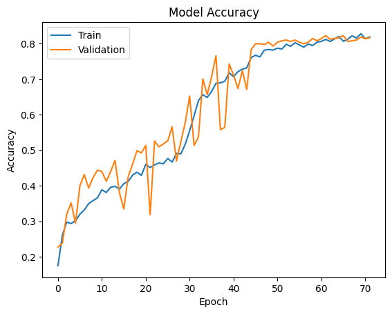

```python
# Model Evaluation
plt.plot(history_2.history['accuracy'])
plt.plot(history_2.history['val_accuracy'])
plt.title('Model Accuracy')
plt.ylabel('Accuracy')
plt.xlabel('Epoch')
plt.legend(['Train', 'Validation'], loc='upper left')
plt.show()
```

Observations:

We can see from the above plot that the training accuracy and validation accuracy is acceptable.

The model does not seem to overfit on the data. However, the graph is noisy until the 50th epoch an then smoothens out a bit

```python
# Evaluate model on test data
accuracy = model2.evaluate(X_test_normalized, y_test_encoded, verbose=2)
```

```
15/15 - 0s - 6ms/step - accuracy: 0.8316 - loss: 0.6360
```

```python
# Generate predictions on test data
# Here we would get the output as probablities for each category
y_pred=model2.predict(X_test_normalized)
```

```
15/15 ━━━━━━━━━━━━━━━━━━━━ 1s 25ms/step
```

```
<sklearn.metrics._plot.confusion_matrix.ConfusionMatrixDisplay at 0x7c7720cf0e50>
```

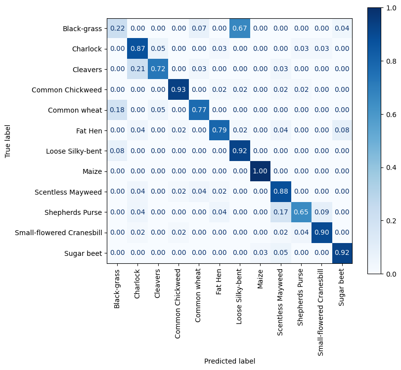

```python
# Obtaining the categorical values from y_test_encoded and y_pred
y_pred_arg=np.argmax(y_pred,axis=1)
y_test_arg=np.argmax(y_test_encoded,axis=1) # argmax() function to obtain the maximum value over each category and obtain their respective classes

# Plotting the Confusion Matrix using confusion matrix() function which is also predefined tensorflow module
confusion_matrix = tf.math.confusion_matrix(y_test_arg,y_pred_arg)
f, ax = plt.subplots(figsize=(8, 7))
ConfusionMatrixDisplay.from_predictions(
    y_test_arg, y_pred_arg,
    display_labels=enc.classes_,
    cmap='Blues',
    ax=ax,
    normalize='true',
    xticks_rotation='vertical',
    values_format='.2f'
)
```

Observations

We observe that some of the classes are not predicted correctly.

We can also see that class0 is mostly misclassified, similar to previous model.

### **Data Augmentation**

Model 3: Basic Convolution Neural Network trained with Augmented dataset with Early stopping and ReduceLRonPlateau

Model 3 will be a CNN model created sequentially, with convolution layers, Pooling layers and fully connected layers with callbacks implemented and dataset augmented

Before building the model, we need to clear the previous model's history from the session.

Also, let's set the seed for random number generators in Numpy, the Random library in Python, and in TensorFlow to be able to reproduce the same results every time we run the code.

```python
# Clearing backend
from tensorflow.keras import backend
backend.clear_session()

# Fixing the seed for random number generators
import random
np.random.seed(42)
random.seed(42)
tf.random.set_seed(42)
```

```python
# All images to be rescaled by 1/255.
train_datagen = ImageDataGenerator(
                              horizontal_flip = True,
                              vertical_flip = False,
                              height_shift_range= 0.1,
                              width_shift_range=0.1,
                              rotation_range=20,
                              fill_mode='nearest'
                              )
```

```python
# Intializing a sequential model
model3 = Sequential()

# Adding first conv layer with 32 filters and kernel size 3x3 , padding 'same'
model3.add(Conv2D(32, (3, 3), activation='relu', padding="same", input_shape=(64, 64, 3)))
model3.add(MaxPooling2D((2, 2), padding = 'same'))

# Adding second conv layer with 64 filters and kernel size 3x3 , padding 'same'
model3.add(Conv2D(64, (3, 3), activation='relu', padding="same"))
model3.add(MaxPooling2D((2, 2), padding = 'same'))
model3.add(BatchNormalization())

# Adding third conv layer with 128 filters and kernel size 3x3 , padding 'same'
model3.add(Conv2D(128, (3, 3), activation='relu', padding="same"))
model3.add(MaxPooling2D((2, 2), padding = 'same'))

# Adding fourth conv layer with 256 filters and kernel size 3x3 , padding 'same'
model3.add(Conv2D(256, (3, 3), activation='relu', padding="same"))
model3.add(MaxPooling2D((2, 2), padding = 'same'))
model3.add(Dropout(0.3))

# flattening the output of the conv layer after max pooling to make it ready for creating dense connections
model3.add(Flatten())

# Adding a fully connected dense layer with 100 neurons
model3.add(Dense(16, activation='relu'))
model3.add(Dropout(0.3))

# Adding the output layer with 10 neurons and activation functions as softmax since this is a multi-class classification problem
model3.add(Dense(12, activation='softmax'))

# Using Adam Optimizer
opt=Adam()

# Compile model
model3.compile(optimizer=opt, loss='categorical_crossentropy', metrics=['accuracy'])

# Generating the summary of the model
model3.summary()
```

```
Model: "sequential"
```

```
┏━━━━━━━━━━━━━━━━━━━━━━━━━━━━━━━━━━━━━━┳━━━━━━━━━━━━━━━━━━━━━━━━━━━━━┳━━━━━━━━━━━━━━━━━┓
┃ Layer (type)                         ┃ Output Shape                ┃         Param # ┃
┡━━━━━━━━━━━━━━━━━━━━━━━━━━━━━━━━━━━━━━╇━━━━━━━━━━━━━━━━━━━━━━━━━━━━━╇━━━━━━━━━━━━━━━━━┩
│ conv2d (Conv2D)                      │ (None, 64, 64, 32)          │             896 │
├──────────────────────────────────────┼─────────────────────────────┼─────────────────┤
│ max_pooling2d (MaxPooling2D)         │ (None, 32, 32, 32)          │               0 │
├──────────────────────────────────────┼─────────────────────────────┼─────────────────┤
│ conv2d_1 (Conv2D)                    │ (None, 32, 32, 64)          │          18,496 │
├──────────────────────────────────────┼─────────────────────────────┼─────────────────┤
│ max_pooling2d_1 (MaxPooling2D)       │ (None, 16, 16, 64)          │               0 │
├──────────────────────────────────────┼─────────────────────────────┼─────────────────┤
│ batch_normalization                  │ (None, 16, 16, 64)          │             256 │
│ (BatchNormalization)                 │                             │                 │
├──────────────────────────────────────┼─────────────────────────────┼─────────────────┤
│ conv2d_2 (Conv2D)                    │ (None, 16, 16, 128)         │          73,856 │
├──────────────────────────────────────┼─────────────────────────────┼─────────────────┤
│ max_pooling2d_2 (MaxPooling2D)       │ (None, 8, 8, 128)           │               0 │
├──────────────────────────────────────┼─────────────────────────────┼─────────────────┤
│ conv2d_3 (Conv2D)                    │ (None, 8, 8, 256)           │         295,168 │
├──────────────────────────────────────┼─────────────────────────────┼─────────────────┤
│ max_pooling2d_3 (MaxPooling2D)       │ (None, 4, 4, 256)           │               0 │
├──────────────────────────────────────┼─────────────────────────────┼─────────────────┤
│ dropout (Dropout)                    │ (None, 4, 4, 256)           │               0 │
├──────────────────────────────────────┼─────────────────────────────┼─────────────────┤
│ flatten (Flatten)                    │ (None, 4096)                │               0 │
├──────────────────────────────────────┼─────────────────────────────┼─────────────────┤
│ dense (Dense)                        │ (None, 16)                  │          65,552 │
├──────────────────────────────────────┼─────────────────────────────┼─────────────────┤
│ dropout_1 (Dropout)                  │ (None, 16)                  │               0 │
├──────────────────────────────────────┼─────────────────────────────┼─────────────────┤
│ dense_1 (Dense)                      │ (None, 12)                  │             204 │
└──────────────────────────────────────┴─────────────────────────────┴─────────────────┘
```

```
 Total params: 454,428 (1.73 MB)
```

```
 Trainable params: 454,300 (1.73 MB)
```

```
 Non-trainable params: 128 (512.00 B)
```

```python
es_cb = EarlyStopping(
    monitor='val_accuracy',
    patience=10,
    verbose=1,
    restore_best_weights=True,
    # start_from_epoch=10
)

rlrop_cb = ReduceLROnPlateau(
    monitor='val_accuracy',
    patience=7,
    verbose=1
)

callbacks = [es_cb, rlrop_cb]
```

```python
# Fit model on augmented training data set
history_3 = model3.fit(train_datagen.flow(X_train_normalized,y_train_encoded,
                                       batch_size=32,
                                       seed=42,
                                       shuffle=False),
                    epochs=100,
                    steps_per_epoch=X_train_normalized.shape[0],
                    validation_data=(X_val_normalized,y_val_encoded),
                    verbose=1,
                    callbacks=callbacks)
```

```
3800/3800 ━━━━━━━━━━━━━━━━━━━━ 13s 2ms/step - accuracy: 0.2350 - loss: 2.2606 - val_accuracy: 0.3579 - val_loss: 2.4181 - learning_rate: 0.0010
3800/3800 ━━━━━━━━━━━━━━━━━━━━ 6s 1ms/step - accuracy: 0.3407 - loss: 1.8897 - val_accuracy: 0.3684 - val_loss: 2.2745 - learning_rate: 0.0010
3800/3800 ━━━━━━━━━━━━━━━━━━━━ 5s 1ms/step - accuracy: 0.4018 - loss: 1.6910 - val_accuracy: 0.2674 - val_loss: 2.2238 - learning_rate: 0.0010
3800/3800 ━━━━━━━━━━━━━━━━━━━━ 6s 2ms/step - accuracy: 0.4622 - loss: 1.5402 - val_accuracy: 0.6063 - val_loss: 1.6697 - learning_rate: 0.0010
3800/3800 ━━━━━━━━━━━━━━━━━━━━ 5s 1ms/step - accuracy: 0.4919 - loss: 1.4354 - val_accuracy: 0.6147 - val_loss: 1.3804 - learning_rate: 0.0010
3800/3800 ━━━━━━━━━━━━━━━━━━━━ 5s 1ms/step - accuracy: 0.5182 - loss: 1.3224 - val_accuracy: 0.5516 - val_loss: 1.3531 - learning_rate: 0.0010
3800/3800 ━━━━━━━━━━━━━━━━━━━━ 6s 2ms/step - accuracy: 0.5251 - loss: 1.3031 - val_accuracy: 0.5768 - val_loss: 1.3262 - learning_rate: 0.0010
3800/3800 ━━━━━━━━━━━━━━━━━━━━ 4s 1ms/step - accuracy: 0.5378 - loss: 1.2505 - val_accuracy: 0.6358 - val_loss: 1.1508 - learning_rate: 0.0010
3800/3800 ━━━━━━━━━━━━━━━━━━━━ 6s 1ms/step - accuracy: 0.5440 - loss: 1.2213 - val_accuracy: 0.7011 - val_loss: 0.9466 - learning_rate: 0.0010
3800/3800 ━━━━━━━━━━━━━━━━━━━━ 9s 1ms/step - accuracy: 0.5848 - loss: 1.1440 - val_accuracy: 0.7032 - val_loss: 0.8676 - learning_rate: 0.0010
3800/3800 ━━━━━━━━━━━━━━━━━━━━ 6s 2ms/step - accuracy: 0.5847 - loss: 1.1437 - val_accuracy: 0.5747 - val_loss: 1.2957 - learning_rate: 0.0010
3800/3800 ━━━━━━━━━━━━━━━━━━━━ 5s 1ms/step - accuracy: 0.6000 - loss: 1.0764 - val_accuracy: 0.6695 - val_loss: 0.9618 - learning_rate: 0.0010
3800/3800 ━━━━━━━━━━━━━━━━━━━━ 6s 1ms/step - accuracy: 0.6107 - loss: 1.0571 - val_accuracy: 0.7516 - val_loss: 0.7866 - learning_rate: 0.0010
3800/3800 ━━━━━━━━━━━━━━━━━━━━ 5s 1ms/step - accuracy: 0.6238 - loss: 1.0236 - val_accuracy: 0.6758 - val_loss: 0.9456 - learning_rate: 0.0010
3800/3800 ━━━━━━━━━━━━━━━━━━━━ 5s 1ms/step - accuracy: 0.6385 - loss: 0.9752 - val_accuracy: 0.6316 - val_loss: 1.3546 - learning_rate: 0.0010
3800/3800 ━━━━━━━━━━━━━━━━━━━━ 7s 2ms/step - accuracy: 0.6488 - loss: 0.9446 - val_accuracy: 0.6337 - val_loss: 0.9546 - learning_rate: 0.0010
3800/3800 ━━━━━━━━━━━━━━━━━━━━ 9s 1ms/step - accuracy: 0.6613 - loss: 0.9107 - val_accuracy: 0.8211 - val_loss: 0.5708 - learning_rate: 0.0010
3800/3800 ━━━━━━━━━━━━━━━━━━━━ 5s 1ms/step - accuracy: 0.6754 - loss: 0.8551 - val_accuracy: 0.7663 - val_loss: 0.7135 - learning_rate: 0.0010
3800/3800 ━━━━━━━━━━━━━━━━━━━━ 5s 1ms/step - accuracy: 0.7008 - loss: 0.8181 - val_accuracy: 0.7179 - val_loss: 0.8979 - learning_rate: 0.0010
3800/3800 ━━━━━━━━━━━━━━━━━━━━ 6s 2ms/step - accuracy: 0.7064 - loss: 0.7999 - val_accuracy: 0.7937 - val_loss: 0.6147 - learning_rate: 0.0010
3800/3800 ━━━━━━━━━━━━━━━━━━━━ 5s 1ms/step - accuracy: 0.7187 - loss: 0.7711 - val_accuracy: 0.7853 - val_loss: 0.7296 - learning_rate: 0.0010
3800/3800 ━━━━━━━━━━━━━━━━━━━━ 6s 2ms/step - accuracy: 0.7291 - loss: 0.7489 - val_accuracy: 0.7832 - val_loss: 0.6534 - learning_rate: 0.0010
3800/3800 ━━━━━━━━━━━━━━━━━━━━ 5s 1ms/step - accuracy: 0.7360 - loss: 0.7100 - val_accuracy: 0.6421 - val_loss: 1.5752 - learning_rate: 0.0010
3800/3800 ━━━━━━━━━━━━━━━━━━━━ 5s 1ms/step - accuracy: 0.7511 - loss: 0.6615 - val_accuracy: 0.8232 - val_loss: 0.5317 - learning_rate: 0.0010
3800/3800 ━━━━━━━━━━━━━━━━━━━━ 6s 2ms/step - accuracy: 0.7577 - loss: 0.6497 - val_accuracy: 0.8126 - val_loss: 0.5579 - learning_rate: 0.0010
3800/3800 ━━━━━━━━━━━━━━━━━━━━ 9s 1ms/step - accuracy: 0.7496 - loss: 0.6735 - val_accuracy: 0.7937 - val_loss: 0.6115 - learning_rate: 0.0010
3800/3800 ━━━━━━━━━━━━━━━━━━━━ 6s 2ms/step - accuracy: 0.7567 - loss: 0.6732 - val_accuracy: 0.8568 - val_loss: 0.4442 - learning_rate: 0.0010
3800/3800 ━━━━━━━━━━━━━━━━━━━━ 9s 1ms/step - accuracy: 0.7696 - loss: 0.6077 - val_accuracy: 0.7537 - val_loss: 0.8312 - learning_rate: 0.0010
3800/3800 ━━━━━━━━━━━━━━━━━━━━ 10s 1ms/step - accuracy: 0.7766 - loss: 0.6062 - val_accuracy: 0.8211 - val_loss: 0.5423 - learning_rate: 0.0010
3800/3800 ━━━━━━━━━━━━━━━━━━━━ 6s 2ms/step - accuracy: 0.7927 - loss: 0.5790 - val_accuracy: 0.8358 - val_loss: 0.4796 - learning_rate: 0.0010
3800/3800 ━━━━━━━━━━━━━━━━━━━━ 5s 1ms/step - accuracy: 0.7770 - loss: 0.5983 - val_accuracy: 0.8526 - val_loss: 0.3881 - learning_rate: 0.0010
3800/3800 ━━━━━━━━━━━━━━━━━━━━ 6s 1ms/step - accuracy: 0.7929 - loss: 0.5718 - val_accuracy: 0.6968 - val_loss: 1.1004 - learning_rate: 0.0010
3800/3800 ━━━━━━━━━━━━━━━━━━━━ 5s 1ms/step - accuracy: 0.7885 - loss: 0.5788 - val_accuracy: 0.8316 - val_loss: 0.4908 - learning_rate: 0.0010
 118/3800 ━━━━━━━━━━━━━━━━━━━━ 2:20 38ms/step - accuracy: 0.7851 - loss: 0.5912
Epoch 34: ReduceLROnPlateau reducing learning rate to 0.00010000000474974513.
3800/3800 ━━━━━━━━━━━━━━━━━━━━ 5s 1ms/step - accuracy: 0.7896 - loss: 0.5600 - val_accuracy: 0.7937 - val_loss: 0.6725 - learning_rate: 0.0010
3800/3800 ━━━━━━━━━━━━━━━━━━━━ 6s 2ms/step - accuracy: 0.8126 - loss: 0.5001 - val_accuracy: 0.8758 - val_loss: 0.3825 - learning_rate: 1.0000e-04
```

[output cut: 19 more lines]

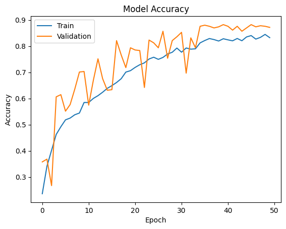

```python
# Model Evaluation
plt.plot(history_3.history['accuracy'])
plt.plot(history_3.history['val_accuracy'])
plt.title('Model Accuracy')
plt.ylabel('Accuracy')
plt.xlabel('Epoch')
plt.legend(['Train', 'Validation'], loc='upper left')
plt.show()
```

Observations:

We can see from the above plot that the training accuracy and validation accuracy is very good

```python
# Evaluate model on test data
accuracy = model3.evaluate(X_test_normalized, y_test_encoded, verbose=2)
```

```
15/15 - 0s - 6ms/step - accuracy: 0.8905 - loss: 0.3530
```

```python
# Generate predictions on test data
# Here we would get the output as probablities for each category
y_pred=model3.predict(X_test_normalized)
```

```
15/15 ━━━━━━━━━━━━━━━━━━━━ 1s 30ms/step
```

```
<sklearn.metrics._plot.confusion_matrix.ConfusionMatrixDisplay at 0x79a26053cb90>
```

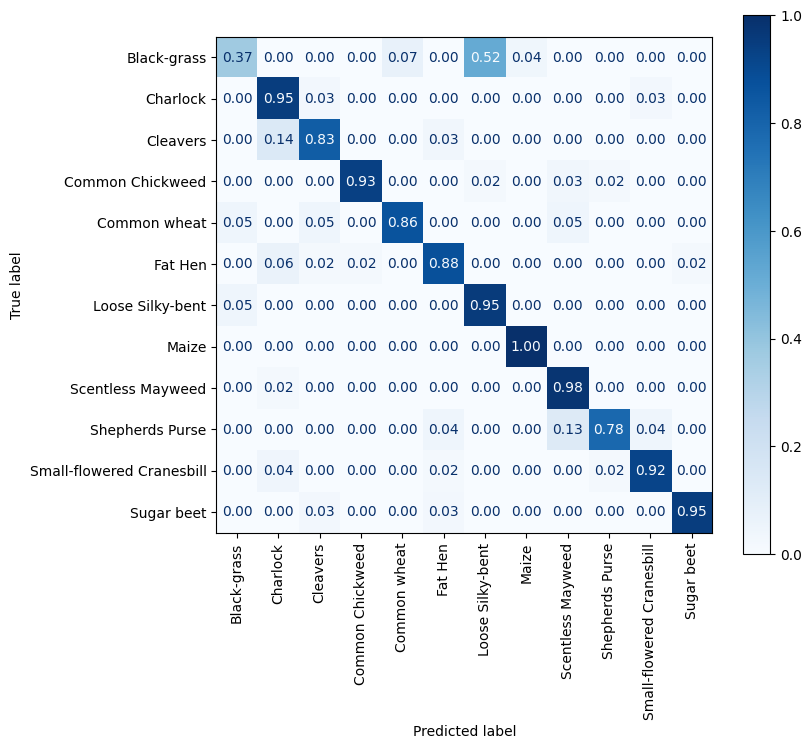

```python
# Obtaining the categorical values from y_test_encoded and y_pred
y_pred_arg=np.argmax(y_pred,axis=1)
y_test_arg=np.argmax(y_test_encoded,axis=1) # argmax() function to obtain the maximum value over each category and obtain their respective classes

# Plotting the Confusion Matrix using confusion matrix() function which is also predefined tensorflow module
confusion_matrix = tf.math.confusion_matrix(y_test_arg,y_pred_arg)
f, ax = plt.subplots(figsize=(8, 7))
ConfusionMatrixDisplay.from_predictions(
    y_test_arg, y_pred_arg,
    display_labels=enc.classes_,
    cmap='Blues',
    ax=ax,
    normalize='true',
    xticks_rotation='vertical',
    values_format='.2f'
)
```

Observations

We observe that most of the classes are predicted correctly.

We can also see that class0 is mostly misclassified, but the % is much better than the previous model.

## **Transfer Learning using VGG16**

VGG16, which was trained on the ImageNet dataset is a pre-built model

For training VGG16, we will directly use the convolutional and pooling layers and freeze their weights i.e. no training will be done on them. For classification, we will replace the existing fully-connected layers with FC layers created specifically for our problem.

Model 4: VGG16 Convolution Neural Network trained with augmented dataset with Early stopping and ReduceLRonPlateau

Model 4 will be a CNN model created sequentially, with convolution layers and Pooling layers retained from VGG16 model and fully connected layers with callbacks implemented

Before building the model, we need to clear the previous model's history from the session.

Also, let's set the seed for random number generators in Numpy, the Random library in Python, and in TensorFlow to be able to reproduce the same results every time we run the code.

```python
# Clearing backend
from tensorflow.keras import backend
backend.clear_session()

# Fixing the seed for random number generators
import random
np.random.seed(42)
random.seed(42)
tf.random.set_seed(42)
```

```python
from tensorflow.keras.models import Model
from tensorflow.keras.applications.vgg16 import VGG16

vgg_model = VGG16(weights='imagenet', include_top = False, input_shape=(64,64,3))
vgg_model.summary()
```

```
Model: "vgg16"
```

```
┏━━━━━━━━━━━━━━━━━━━━━━━━━━━━━━━━━━━━━━┳━━━━━━━━━━━━━━━━━━━━━━━━━━━━━┳━━━━━━━━━━━━━━━━━┓
┃ Layer (type)                         ┃ Output Shape                ┃         Param # ┃
┡━━━━━━━━━━━━━━━━━━━━━━━━━━━━━━━━━━━━━━╇━━━━━━━━━━━━━━━━━━━━━━━━━━━━━╇━━━━━━━━━━━━━━━━━┩
│ input_layer (InputLayer)             │ (None, 64, 64, 3)           │               0 │
├──────────────────────────────────────┼─────────────────────────────┼─────────────────┤
│ block1_conv1 (Conv2D)                │ (None, 64, 64, 64)          │           1,792 │
├──────────────────────────────────────┼─────────────────────────────┼─────────────────┤
│ block1_conv2 (Conv2D)                │ (None, 64, 64, 64)          │          36,928 │
├──────────────────────────────────────┼─────────────────────────────┼─────────────────┤
│ block1_pool (MaxPooling2D)           │ (None, 32, 32, 64)          │               0 │
├──────────────────────────────────────┼─────────────────────────────┼─────────────────┤
│ block2_conv1 (Conv2D)                │ (None, 32, 32, 128)         │          73,856 │
├──────────────────────────────────────┼─────────────────────────────┼─────────────────┤
│ block2_conv2 (Conv2D)                │ (None, 32, 32, 128)         │         147,584 │
├──────────────────────────────────────┼─────────────────────────────┼─────────────────┤
│ block2_pool (MaxPooling2D)           │ (None, 16, 16, 128)         │               0 │
├──────────────────────────────────────┼─────────────────────────────┼─────────────────┤
│ block3_conv1 (Conv2D)                │ (None, 16, 16, 256)         │         295,168 │
├──────────────────────────────────────┼─────────────────────────────┼─────────────────┤
│ block3_conv2 (Conv2D)                │ (None, 16, 16, 256)         │         590,080 │
├──────────────────────────────────────┼─────────────────────────────┼─────────────────┤
│ block3_conv3 (Conv2D)                │ (None, 16, 16, 256)         │         590,080 │
├──────────────────────────────────────┼─────────────────────────────┼─────────────────┤
│ block3_pool (MaxPooling2D)           │ (None, 8, 8, 256)           │               0 │
├──────────────────────────────────────┼─────────────────────────────┼─────────────────┤
│ block4_conv1 (Conv2D)                │ (None, 8, 8, 512)           │       1,180,160 │
├──────────────────────────────────────┼─────────────────────────────┼─────────────────┤
│ block4_conv2 (Conv2D)                │ (None, 8, 8, 512)           │       2,359,808 │
├──────────────────────────────────────┼─────────────────────────────┼─────────────────┤
│ block4_conv3 (Conv2D)                │ (None, 8, 8, 512)           │       2,359,808 │
├──────────────────────────────────────┼─────────────────────────────┼─────────────────┤
│ block4_pool (MaxPooling2D)           │ (None, 4, 4, 512)           │               0 │
├──────────────────────────────────────┼─────────────────────────────┼─────────────────┤
│ block5_conv1 (Conv2D)                │ (None, 4, 4, 512)           │       2,359,808 │
├──────────────────────────────────────┼─────────────────────────────┼─────────────────┤
│ block5_conv2 (Conv2D)                │ (None, 4, 4, 512)           │       2,359,808 │
├──────────────────────────────────────┼─────────────────────────────┼─────────────────┤
│ block5_conv3 (Conv2D)                │ (None, 4, 4, 512)           │       2,359,808 │
├──────────────────────────────────────┼─────────────────────────────┼─────────────────┤
│ block5_pool (MaxPooling2D)           │ (None, 2, 2, 512)           │               0 │
└──────────────────────────────────────┴─────────────────────────────┴─────────────────┘
```

```
 Total params: 14,714,688 (56.13 MB)
```

```
 Trainable params: 14,714,688 (56.13 MB)
```

```
 Non-trainable params: 0 (0.00 B)
```

```python
# Making all the layers of the VGG model non-trainable. i.e. freezing them
for layer in vgg_model.layers:
    layer.trainable = False
vgg_model.summary()
```

```
Model: "vgg16"
```

```
┏━━━━━━━━━━━━━━━━━━━━━━━━━━━━━━━━━━━━━━┳━━━━━━━━━━━━━━━━━━━━━━━━━━━━━┳━━━━━━━━━━━━━━━━━┓
┃ Layer (type)                         ┃ Output Shape                ┃         Param # ┃
┡━━━━━━━━━━━━━━━━━━━━━━━━━━━━━━━━━━━━━━╇━━━━━━━━━━━━━━━━━━━━━━━━━━━━━╇━━━━━━━━━━━━━━━━━┩
│ input_layer (InputLayer)             │ (None, 64, 64, 3)           │               0 │
├──────────────────────────────────────┼─────────────────────────────┼─────────────────┤
│ block1_conv1 (Conv2D)                │ (None, 64, 64, 64)          │           1,792 │
├──────────────────────────────────────┼─────────────────────────────┼─────────────────┤
│ block1_conv2 (Conv2D)                │ (None, 64, 64, 64)          │          36,928 │
├──────────────────────────────────────┼─────────────────────────────┼─────────────────┤
│ block1_pool (MaxPooling2D)           │ (None, 32, 32, 64)          │               0 │
├──────────────────────────────────────┼─────────────────────────────┼─────────────────┤
│ block2_conv1 (Conv2D)                │ (None, 32, 32, 128)         │          73,856 │
├──────────────────────────────────────┼─────────────────────────────┼─────────────────┤
│ block2_conv2 (Conv2D)                │ (None, 32, 32, 128)         │         147,584 │
├──────────────────────────────────────┼─────────────────────────────┼─────────────────┤
│ block2_pool (MaxPooling2D)           │ (None, 16, 16, 128)         │               0 │
├──────────────────────────────────────┼─────────────────────────────┼─────────────────┤
│ block3_conv1 (Conv2D)                │ (None, 16, 16, 256)         │         295,168 │
├──────────────────────────────────────┼─────────────────────────────┼─────────────────┤
│ block3_conv2 (Conv2D)                │ (None, 16, 16, 256)         │         590,080 │
├──────────────────────────────────────┼─────────────────────────────┼─────────────────┤
│ block3_conv3 (Conv2D)                │ (None, 16, 16, 256)         │         590,080 │
├──────────────────────────────────────┼─────────────────────────────┼─────────────────┤
│ block3_pool (MaxPooling2D)           │ (None, 8, 8, 256)           │               0 │
├──────────────────────────────────────┼─────────────────────────────┼─────────────────┤
│ block4_conv1 (Conv2D)                │ (None, 8, 8, 512)           │       1,180,160 │
├──────────────────────────────────────┼─────────────────────────────┼─────────────────┤
│ block4_conv2 (Conv2D)                │ (None, 8, 8, 512)           │       2,359,808 │
├──────────────────────────────────────┼─────────────────────────────┼─────────────────┤
│ block4_conv3 (Conv2D)                │ (None, 8, 8, 512)           │       2,359,808 │
├──────────────────────────────────────┼─────────────────────────────┼─────────────────┤
│ block4_pool (MaxPooling2D)           │ (None, 4, 4, 512)           │               0 │
├──────────────────────────────────────┼─────────────────────────────┼─────────────────┤
│ block5_conv1 (Conv2D)                │ (None, 4, 4, 512)           │       2,359,808 │
├──────────────────────────────────────┼─────────────────────────────┼─────────────────┤
│ block5_conv2 (Conv2D)                │ (None, 4, 4, 512)           │       2,359,808 │
├──────────────────────────────────────┼─────────────────────────────┼─────────────────┤
│ block5_conv3 (Conv2D)                │ (None, 4, 4, 512)           │       2,359,808 │
├──────────────────────────────────────┼─────────────────────────────┼─────────────────┤
│ block5_pool (MaxPooling2D)           │ (None, 2, 2, 512)           │               0 │
└──────────────────────────────────────┴─────────────────────────────┴─────────────────┘
```

```
 Total params: 14,714,688 (56.13 MB)
```

```
 Trainable params: 0 (0.00 B)
```

```
 Non-trainable params: 14,714,688 (56.13 MB)
```

```python
# Intializing a sequential model
model4 = Sequential()

# Adding the convolutional part of the VGG16 model from above
model4.add(vgg_model)
model4.add(BatchNormalization())

# flattening the output of the conv layer after max pooling to make it ready for creating dense connections
model4.add(Flatten())

# Adding a fully connected dense layer with 16 neurons
model4.add(Dense(32, activation='relu'))
model4.add(Dropout(0.3))

model4.add(Dense(16, activation='relu'))


# Adding the output layer with 10 neurons and activation functions as softmax since this is a multi-class classification problem
model4.add(Dense(12, activation='softmax'))

# Using Adam optimizer
opt=Adam()

# Compile model
model4.compile(optimizer=opt, loss='categorical_crossentropy', metrics=['accuracy'])

# Generating the summary of the model
model4.summary()
```

```
Model: "sequential"
```

```
┏━━━━━━━━━━━━━━━━━━━━━━━━━━━━━━━━━━━━━━┳━━━━━━━━━━━━━━━━━━━━━━━━━━━━━┳━━━━━━━━━━━━━━━━━┓
┃ Layer (type)                         ┃ Output Shape                ┃         Param # ┃
┡━━━━━━━━━━━━━━━━━━━━━━━━━━━━━━━━━━━━━━╇━━━━━━━━━━━━━━━━━━━━━━━━━━━━━╇━━━━━━━━━━━━━━━━━┩
│ vgg16 (Functional)                   │ (None, 2, 2, 512)           │      14,714,688 │
├──────────────────────────────────────┼─────────────────────────────┼─────────────────┤
│ batch_normalization                  │ (None, 2, 2, 512)           │           2,048 │
│ (BatchNormalization)                 │                             │                 │
├──────────────────────────────────────┼─────────────────────────────┼─────────────────┤
│ flatten (Flatten)                    │ (None, 2048)                │               0 │
├──────────────────────────────────────┼─────────────────────────────┼─────────────────┤
│ dense (Dense)                        │ (None, 32)                  │          65,568 │
├──────────────────────────────────────┼─────────────────────────────┼─────────────────┤
│ dropout (Dropout)                    │ (None, 32)                  │               0 │
├──────────────────────────────────────┼─────────────────────────────┼─────────────────┤
│ dense_1 (Dense)                      │ (None, 16)                  │             528 │
├──────────────────────────────────────┼─────────────────────────────┼─────────────────┤
│ dense_2 (Dense)                      │ (None, 12)                  │             204 │
└──────────────────────────────────────┴─────────────────────────────┴─────────────────┘
```

```
 Total params: 14,783,036 (56.39 MB)
```

```
 Trainable params: 67,324 (262.98 KB)
```

```
 Non-trainable params: 14,715,712 (56.14 MB)
```

```python
es_cb = EarlyStopping(
    monitor='val_accuracy',
    patience=10,
    verbose=1,
    restore_best_weights=True,
    start_from_epoch=10
)

rlrop_cb = ReduceLROnPlateau(
    monitor='val_accuracy',
    patience=7,
    verbose=1
)

callbacks = [es_cb, rlrop_cb]
```

```python
history_4 = model4.fit(train_datagen.flow(X_train_normalized,y_train_encoded,
                                       batch_size=32,
                                       seed=42,
                                       shuffle=False),
                    epochs=100,
                    steps_per_epoch=X_train_normalized.shape[0],
                    validation_data=(X_val_normalized,y_val_encoded),
                    verbose=1,
                    callbacks=callbacks)
```

[output not shown]

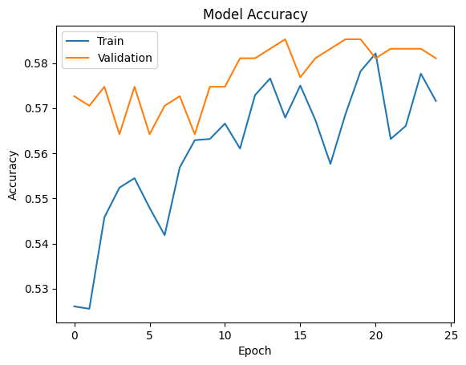

```python
# Model Evaluation
plt.plot(history_4.history['accuracy'])
plt.plot(history_4.history['val_accuracy'])
plt.title('Model Accuracy')
plt.ylabel('Accuracy')
plt.xlabel('Epoch')
plt.legend(['Train', 'Validation'], loc='upper left')
plt.show()
```

Observations

The training and validation accuracy is poor compared toprevious models

```python
# Evaluate model on test data
accuracy = model4.evaluate(X_test_normalized, y_test_encoded, verbose=2)
```

```
15/15 - 0s - 30ms/step - accuracy: 0.6000 - loss: 1.1655
```

```python
# Generate predictions on test data
# Here we would get the output as probablities for each category
y_pred=model4.predict(X_test_normalized)
```

```
15/15 ━━━━━━━━━━━━━━━━━━━━ 2s 65ms/step
```

```
<sklearn.metrics._plot.confusion_matrix.ConfusionMatrixDisplay at 0x7c77208e9a10>
```

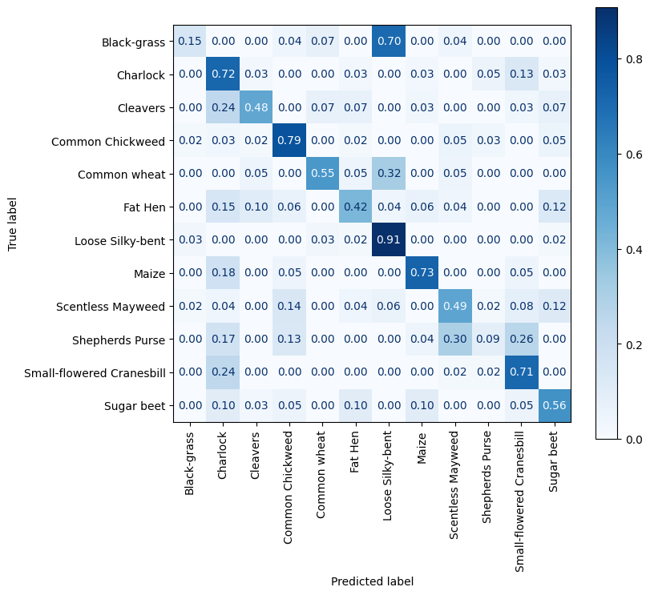

```python
# Obtaining the categorical values from y_test_encoded and y_pred
y_pred_arg=np.argmax(y_pred,axis=1)
y_test_arg=np.argmax(y_test_encoded,axis=1) # argmax() function to obtain the maximum value over each category and obtain their respective classes

# Plotting the Confusion Matrix using confusion matrix() function which is also predefined tensorflow module
confusion_matrix = tf.math.confusion_matrix(y_test_arg,y_pred_arg)
f, ax = plt.subplots(figsize=(8, 7))
ConfusionMatrixDisplay.from_predictions(
    y_test_arg, y_pred_arg,
    display_labels=enc.classes_,
    cmap='Blues',
    ax=ax,
    normalize='true',
    xticks_rotation='vertical',
    values_format='.2f'
)
```

We will reject this model

## Final Model

Comment on the final model you have selected and use the same in the below code to visualize the image.

```python
#Consolidated matrix

pd.DataFrame({'Models':['Basic CNN with original dataset','Basic CNN with original dataset, Early stopping and ReduceLRonPlateau',
                        'CNN with Augmented dataset, Early stopping and ReduceLRonPlateau','Transfer Learning with VGG16 CNN, Augmented dataset,
                        Early stopping and ReduceLRonPlateau'],
                        'Train Accuracy':['73%','81%','80%','57%'],
                        'Validation Accuracy':['78%','88%','88%','59%'],
                        'Test Accuracy':['76%','83%','89%','60%']})
```

[output not shown]

Observations

Based on above table, we will pick Model3 as our best model. It has a considerably good performance and has high test accuracy.

### Visualizing the prediction

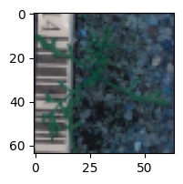

```
1/1 ━━━━━━━━━━━━━━━━━━━━ 0s 269ms/step
Predicted Label ['Scentless Mayweed']
True Label Scentless Mayweed
```

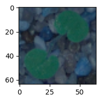

```
1/1 ━━━━━━━━━━━━━━━━━━━━ 0s 30ms/step
Predicted Label ['Small-flowered Cranesbill']
True Label Small-flowered Cranesbill
```

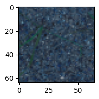

```
1/1 ━━━━━━━━━━━━━━━━━━━━ 0s 31ms/step
Predicted Label ['Black-grass']
True Label Black-grass
```

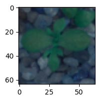

```
1/1 ━━━━━━━━━━━━━━━━━━━━ 0s 30ms/step
Predicted Label ['Scentless Mayweed']
True Label Scentless Mayweed
```

```python
# Visualizing the predicted and correct label of images from test data
plt.figure(figsize=(2,2))
plt.imshow(X_test[2])
plt.show()
## Complete the code to predict the test data using the final model selected
print('Predicted Label', enc.inverse_transform(model3.predict((X_test_normalized[2].reshape(1,64,64,3)))))   # reshaping the input image as we are only trying to predict using a single image
print('True Label', enc.inverse_transform(y_test_encoded)[2])                                               # using inverse_transform() to get the output label from the output vector

plt.figure(figsize=(2,2))
plt.imshow(X_test[33])
plt.show()
## Complete the code to predict the test data using the final model selected
print('Predicted Label', enc.inverse_transform(model3.predict((X_test_normalized[33].reshape(1,64,64,3)))))  # reshaping the input image as we are only trying to predict using a single image
print('True Label', enc.inverse_transform(y_test_encoded)[33])                                              # using inverse_transform() to get the output label from the output vector

plt.figure(figsize=(2,2))
plt.imshow(X_test[59],)
plt.show()
## Complete the code to predict the test data using the final model selected
print('Predicted Label', enc.inverse_transform(model3.predict((X_test_normalized[59].reshape(1,64,64,3)))))  # reshaping the input image as we are only trying to predict using a single image
print('True Label', enc.inverse_transform(y_test_encoded)[59])                                              # using inverse_transform() to get the output label from the output vector

plt.figure(figsize=(2,2))
plt.imshow(X_test[36])
plt.show()
## Complete the code to predict the test data using the final model selected
print('Predicted Label', enc.inverse_transform(model3.predict((X_test_normalized[36].reshape(1,64,64,3)))))  # reshaping the input image as we are only trying to predict using a single image
print('True Label', enc.inverse_transform(y_test_encoded)[36])
```

Observations: The model has correctly predicted the 4 seedlings that were tested.

This indicates that the model can very well generalize on unseen data. Data Augmentation and Learning Rate Reduction Function have played a key role in improving the model's performance

## Actionable Insights and Business Recommendations

Actionable Insights

The model has an accuracy of 89% on the test dataset. The use of data augmentation and learning rate reduction function has been effective in enhancing model performance.

Classes such as 'Black-grass' and 'Common wheat' are under-represented leading to imbalance in the classes. Addressing class imbalance through oversampling/undersampling or class weight function can generate additional synthetic training data. This could help improve model accuracy.

Higher levels of data augmentation can be evaluated (including more features) to enhance performance

Increased training on imbalanced classes is a way to improve performance. This can also be achieved by capturing more intricate patterns in data. Increasing the complexity of the model by adding more layers or neurons could help could help, potentially improving performance on classes with lesser data.

Regularization methods such as dropout layers and Batch Normalization has helped the model fight against overfitting and improve generalization to new data. More dropout or Batch Normlization layers could be tried out.

Business Recommendation

Business should find ways to collect more data especially for under-represented classes so that the model can be trainied on these classes and improve performance